# Assigment 1

## Assess

Check if there is any duplicated genes or features

```r
hgncSym <- unique(exp$Feature)
length(hgncSym) #no duplicated genes
```

```
## [1] 27011
```

```r
features <- unique(colnames(exp))
length(features) #no duplicated features
```

```
## [1] 42
```

## Mapping

Mapping via biomaRt The data that I am working contains HUGO gene symbols so I am going to map it to Ensembl ID

- Map ENSEMBL gene id to HGNC symbols
- Require a stable network connection

```r
myMart <- useMart("ensembl", dataset="hsapiens_gene_ensembl")
tmp <- getBM(filters = "hgnc_symbol",
                      attributes = c("hgnc_symbol",
                                     "ensembl_gene_id"),
                      values = hgncSym,
                      mart = myMart)
```

```
## Cache found
```

Take a look at the new mapped table

```r
head(tmp)
```

```
##   hgnc_symbol ensembl_gene_id
## 1        A1BG ENSG00000121410
## 2    A1BG-AS1 ENSG00000268895
## 3        A1CF ENSG00000148584
## 4         A2M ENSG00000175899
## 5     A2M-AS1 ENSG00000245105
## 6       A2ML1 ENSG00000166535
```

```r
nrow(tmp)  #  26448 ensembl gene id have been retrieved for the 27011 HGNC symbols
```

```
## [1] 26448
```

## Clean

Check duplicates

```r
sum(duplicated(tmp$ensembl_gene_id))
```

```
## [1] 6
```

```r
sum(! (hgncSym) %in% tmp$nsembl_gene_id)
```

```
## [1] 27011
```

To fix those duplicates - Find them

```r
dupEnsembl <- tmp$ensembl_gene_id[duplicated(tmp$ensembl_gene_id)]
tmp[tmp$ensembl_gene_id %in% dupEnsembl, ]
```

```
##       hgnc_symbol ensembl_gene_id
## 2090     C12orf74 ENSG00000187510
## 2955       CCL3L1 ENSG00000277336
## 2956       CCL3L1 ENSG00000277796
## 2957       CCL3L1 ENSG00000277768
## 2958       CCL3L1 ENSG00000276085
## 2959       CCL3L3 ENSG00000277336
## 2960       CCL3L3 ENSG00000277796
## 2961       CCL3L3 ENSG00000277768
## 2962       CCL3L3 ENSG00000276085
## 10993   LINC00595 ENSG00000230417
## 11090   LINC00856 ENSG00000230417
## 17881     PLEKHG7 ENSG00000187510
```

Make sure there is no empty values

```r
tmp <- tmp[ ! (tmp$ensembl_gene_id %in% c("")), ]
```

Only 6 duplicates so we can check it on the ensembl gene portal

```r
tmp <- tmp[!(tmp$hgnc_symbol == "CCL3L3" & tmp$ensembl_gene_id != "ENSG00000276085"), ]
tmp <- tmp[!(tmp$hgnc_symbol == "CCL3L1" & tmp$ensembl_gene_id != "ENSG00000277336"), ]
```

According to Ensembl gene portal - LINC00856 is an external reference matched to LINC00595 - C12orf74 is an external reference matched PLEKHG7 - We can remove both

```r
tmp <- tmp[ ! (tmp$hgnc_symbol %in% c("C12orf74","LINC00856")), ]

#Check duplicates
any(duplicated(tmp$ensembl_gene_id))
```

```
## [1] FALSE
```

Save the mapping

```r
hgnc2Sym <- tmp$hgnc_symbol
names(hgnc2Sym) <- tmp$ensembl_gene_id

head(hgnc2Sym)
```

```
## ENSG00000121410 ENSG00000268895 ENSG00000148584 ENSG00000175899 ENSG00000245105
##          "A1BG"      "A1BG-AS1"          "A1CF"           "A2M"       "A2M-AS1"
## ENSG00000166535
##         "A2ML1"
```

## Normalization

Group all the subtypes/ features

```r
samples <- data.frame(lapply(colnames(exp)[2:42], FUN = function(x){unlist(strsplit(x, "(?=[A-Za-z])(?<=[0-9])|(?=[0-9])(?<=[A-Za-z])", perl=TRUE))[c(1,2)]}))
colnames(samples) <- colnames(exp)[2:42]
rownames(samples) <- c("subtype","num")
samples <- data.frame(t(samples))
```

Compare read counts in different breast tumour subtypes

```r
cpms = cpm(exp[,2:42])
rownames(cpms) <- exp[,1]
# get rid of low counts
keep = rowSums(cpms >1) >=3
exp_filtered = exp[keep,]
dm <-  as.matrix(exp_filtered[,2:42])
rownames(dm) <- exp_filtered$Feature
d <- DGEList(counts=dm, group=samples$subtype)


#Calculate normalization factor
d <- calcNormFactors(d)
normalized_counts <- cpm(d)
normalized_data <- log2(normalized_counts + 1)


#Coverage of the dataset
(nrow(normalized_counts))-(length(hgnc2Sym)) #~ 2.2% of the dataset
```

```
## [1] -4720
```

## Plot

Now, we can see the distrubution of the data

Boxplot - with data from the original data before normalization

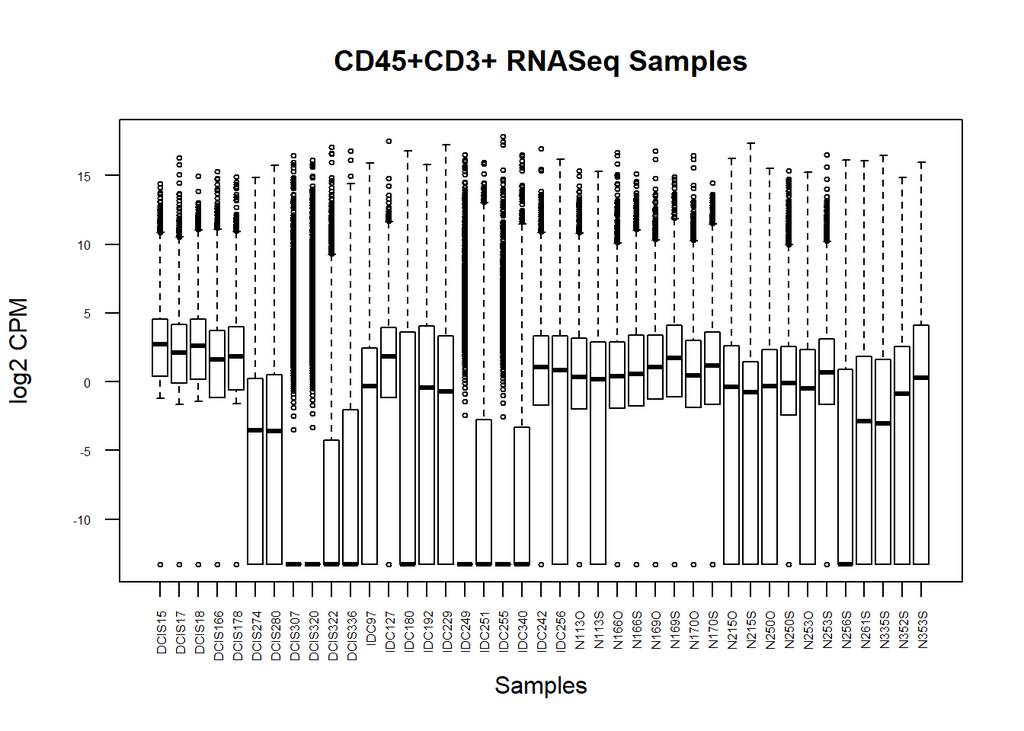

```r
dataPlot <- log2(cpm(exp_filtered[,2:42]) + 0.0001)
boxplot(dataPlot, xlab = "Samples", ylab = "log2 CPM",
                 las = 2, cex = 0.5,
                  cex.axis = 0.5, main = "CD45+CD3+ RNASeq Samples")
```

- View the distrubution using the normalized data

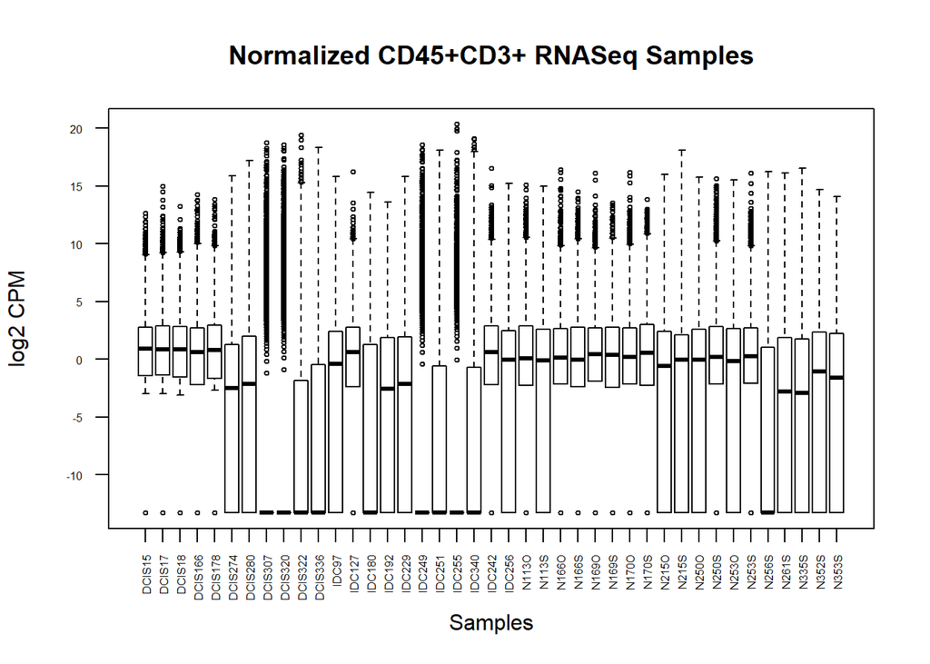

```r
nor_dataPlot <- log2(normalized_counts + 0.0001)
boxplot(nor_dataPlot, xlab = "Samples", ylab = "log2 CPM",
                 las = 2, cex = 0.5,
                  cex.axis = 0.5, main = "Normalized CD45+CD3+ RNASeq Samples")
```

MDS Plot - Compare between all subtypes

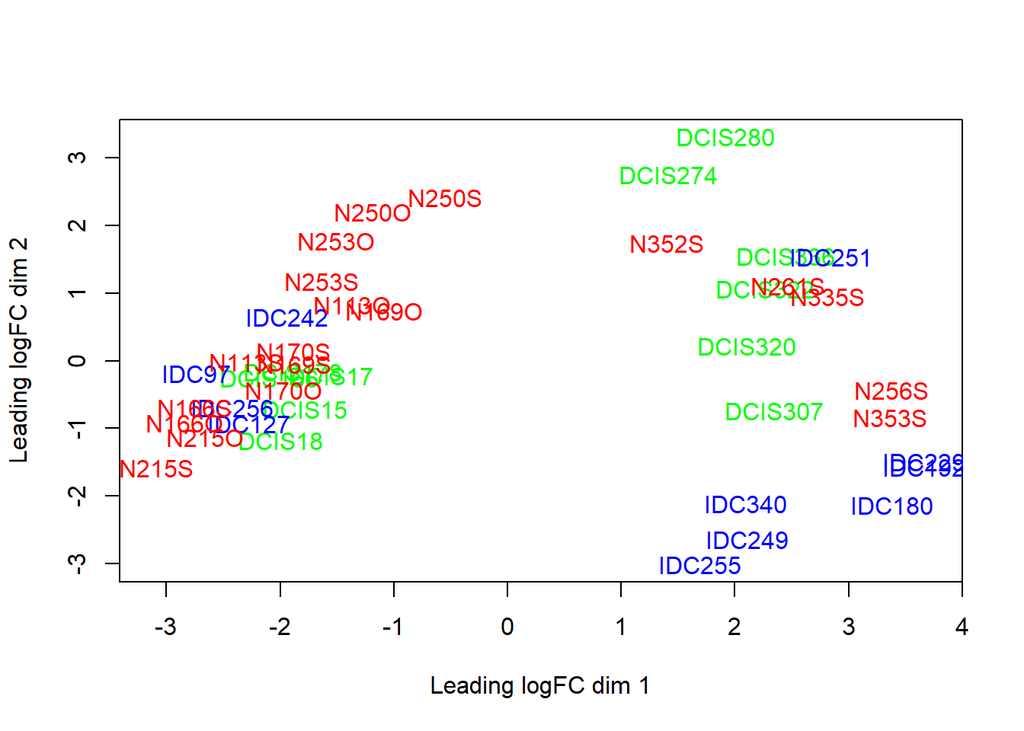

```r
plotMDS(d, labels=rownames(samples),
        col = c("green","blue", "red")[factor(samples$subtype)])
```

Density Plot

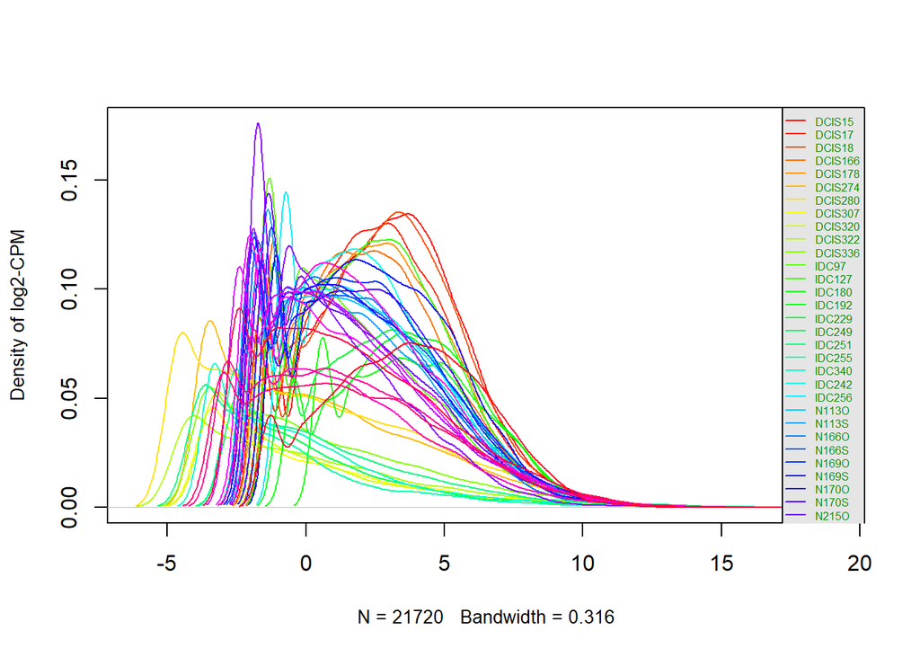

```r
densityCount <- apply(log2(cpm(exp_filtered[,2:42])), 2, density)
xlim <- 0
ylim <- 0
for (i in 1:length(densityCount)) {
  xlim <- range(c(xlim, densityCount[[i]]$x));
  ylim <- range(c(ylim, densityCount[[i]]$y))
}
cols <- rainbow(length(densityCount))
ltys <- rep(1, length(densityCount))

#plot the density graph
plot(densityCount[[1]], xlim=xlim, ylim=ylim, type="n",
     ylab="Density of log2-CPM", main="", cex.lab = 0.85)

for (i in 1:length(densityCount))
  lines(densityCount[[i]], col=cols[i], lty=ltys[i])


legend("topright", colnames(dataPlot),
       col=cols, lty=ltys, cex=0.50,
       border ="blue",  text.col = "green4",
       merge = TRUE, bg = "gray90")
```